# Parallelisation with ‘future’ and Animations

Thomas Petzoldt and Karline Soetaert

July 2021

**Technical Note** regarding compilation of this document:

- Please run this in a folder with write access, the document will create several 100 files.
- Due to simulations, compilation may take a minute or more.
- At the end, you can easily delete all temporary river*.png files.

## A Goody at the End: Easy Parallel Execution with `future`

We have seen that computation of 1D models can take a while, and if we go through the script line by line, we may consider to wait before we enter the next part. Here we can ask: Why not running the simulation in the background or Why not running the three scenarios in parallel on our multiprocessor machine?

This is indeed possible and R has different mechanisms for this, one intriguingly simple is provided by package **future** (Bengtsson 2020). In the following, we just use the `%<-%` operator instead of the common `<-`.

Before that, we set a `plan` that **R** should run this in multiple sessions.

How does it work? After entering sich a code segment, R gives control back to the user, and starts simulation in a separate R worker process in the background. This can then be done for all three scenarios one after each other, because its results (`std0` … `std2`) are not yet needed for the next step. They are eventually needed “in the future” for the `plot` function, so R does not need to return the results immediately.

The following code is again a simple 1D river model, solved with packages **deSolve** (Karline Soetaert, Petzoldt, and Setzer 2010) and **ReacTran** (K. Soetaert and Meysman 2012).

### The model

```r
library(ReacTran)

riverNPZ <- function(time, y, parms) {
  with(as.list(parms), {
    N <- y[       1  :   nbox ]
    P <- y[(  nbox+1):(2*nbox)]
    Z <- y[(2*nbox+1):(3*nbox)]

    p_growth  <- r_pgrow * N / (km_n + N) * P
    z_grazing <- r_zgraz * P / (km_p + P) * Z
    z_loss    <- r_zloss * Z

    n_transport <- tran.1D(C=N, C.up=N.up, v=v, dx=Grid)
    p_transport <- tran.1D(C=P, C.up=P.up, v=v, dx=Grid)
    z_transport <- tran.1D(C=Z, C.up=Z.up, v=v, dx=Grid)

    n_import <- n_transport$flux.up   # in [mmol/m2/d]
    n_export <- n_transport$flux.down

    dN_dt <- c_pn * (-p_growth + (1-asseff) * z_grazing + z_loss) + n_transport$dC
    dP_dt <-         p_growth -               z_grazing           + p_transport$dC
    dZ_dt <-                  +     asseff *  z_grazing - z_loss  + z_transport$dC

    list(c(dN_dt, dP_dt, dZ_dt),
         n_import=n_import, n_export=n_export,
         meanN=mean(N), meanP=mean(P), meanZ=mean(Z))
  })
}
parms <- c(
  r_pgrow    = 0.5,   # phytoplankton growth parameter (1/d)
  r_zgraz    = 0.4,   # zooplankton ingestion parameter (1/d)
  r_zloss    = 0.01,  # zooplankton loss parameter (1/d)

  km_n       = 0.5,   # Monod constant of phyto growth on nutrient (mmol/m3)
  km_p       = 100,   # Monod constant of zoo grazing on phyto (mmol/m3)
  c_pn       = 1/106, # stoichiometric conversion from phosporus P to phyto C (P:C)
  asseff     = 0.3,   # assimilation efficiency of zoo (-)

  v          = 10000, # flow velocity (m/d)
  N.up       = 500,   # nutrient (PO4) in inflow (mmolP/m3)
  P.up       = 10,    # algae in inflow (mmolC/m3)
  Z.up       = 1      # zooplankton in inflow (mmolC/m3)
)

# river morphology
Length <- 500e3  # length of the river (m)
nbox   <- 500    # number of 1D grid cells
Grid   <- setup.grid.1D(L = Length, N = nbox)

# Zoo and Phyto as C and Phosphorus P (mol/m3)
N_init  <- rep(500, times=nbox) # mmolP/m3
P_init  <- rep(100, times=nbox) # mmolC/m3
Z_init  <- rep(10,  times=nbox) # mmolC/m3
y_init  <- c(N_init, P_init, Z_init)
```

### Parallelization

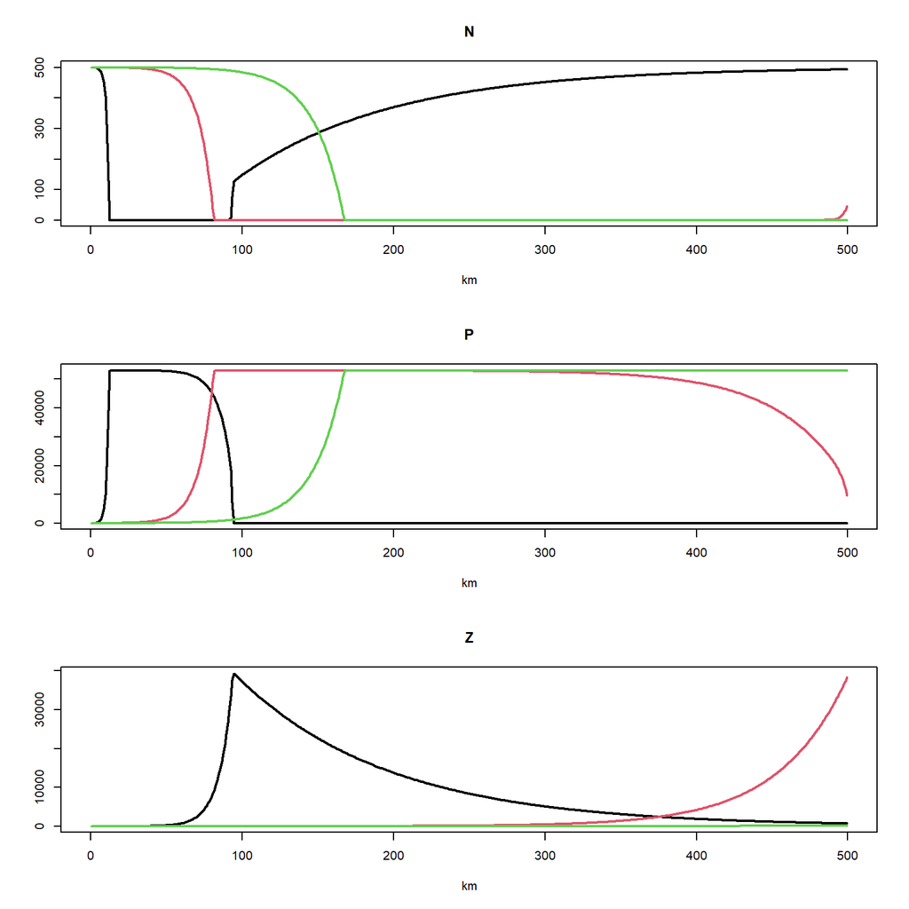

```
##    user  system elapsed
##    0.29    0.05    6.90
```

```r
library("future")

parms1 <- parms2 <- parms
system.time({
  plan(strategy="multisession")
  #plan(strategy="sequential")

  ## three staions for the equilibrium (=stationary state)
  parms["v"] <- 1000  # (m/d)
  std0 %<-% steady.1D(y=y_init, time=0, func=riverNPZ, parms=parms,
                       nspec=3, names=c("N","P","Z"), method="runsteady")

  parms1["v"] <- 5000  # m/d
  std1 %<-% steady.1D(y=y_init, time=0, func=riverNPZ, parms=parms1,
                       nspec=3, names=c("N","P","Z"), method="runsteady")

  parms2["v"] <- 10000 # m/d
  std2 %<-% steady.1D(y=y_init, time=0, func=riverNPZ, parms=parms2,
                       nspec=3, names=c("N","P","Z"), method="runsteady")

  plot(std0, std1, std2, mfrow=c(3,1), grid=Grid$x.mid/1000, lty=1, lwd=2, xlab="km")

  ## and a dynamic simulation (= nonstationary)
  time_seq <- seq(from = 0, to = 200, length.out=201)
  dynamic  %<-% ode.1D(y=y_init, times=time_seq, func=riverNPZ, parms=parms, nspec=3)
})
```

Instead of parallelization, or in addition to it, it is also possible to make the model itself faster. Typical means are vectorization (that is already the case for the river model), and compiled code. Here the model is written in C or Fortran and then linked to R. Depending on the type of the model and how good it can be vectorized, simulations can then be 2 to 200 times faster, in particular if the model cannot be written in matrix notation. The C or Fortran code can be written by hand or created from a code generator. Here, manual programming is not that difficult, because only the numerical parts need to be encoded. More about this can be found in the [package vignettte](https://cran.r-project.org/web/packages/deSolve/vignettes/compiledCode.pdf) of **deSolve** and in a [small tutorial](https://tpetzoldt.github.io/deSolve-compiled/deSolve-compiled.html) on Github.

The C or Fortran code can also be created with a code generator, e.g. **cOde** (Kaschek et al. 2019) or **odin** (FitzJohn 2021). Furthermore, package **rodeo** Kneis (2021) can generate **deSolve** compatible Fortran code directly from a tabular description (stoichiometry table or Petersen-Gujer-matrix) of the model. It is also able to generate code for 1D models.

## Visualization of multi-dimensional model results

Dynamic models are multi-dimensional. Let’s say we have a 1D model as follows, we have 3 dimensions (time, space, value) for each state variable. In such cases it makes sense to use volor image graphics (also called [Hovmöller diagrams](https://en.wikipedia.org/wiki/Hovm%C3%B6ller_diagram)) or animations.

### Color image diagram

Color image diagrams can be created with **R**’s `image` function. Some more options are available in packages **plot3D** (Karline Soetaert 2021b) and **OceanView** (Karline Soetaert 2021a).

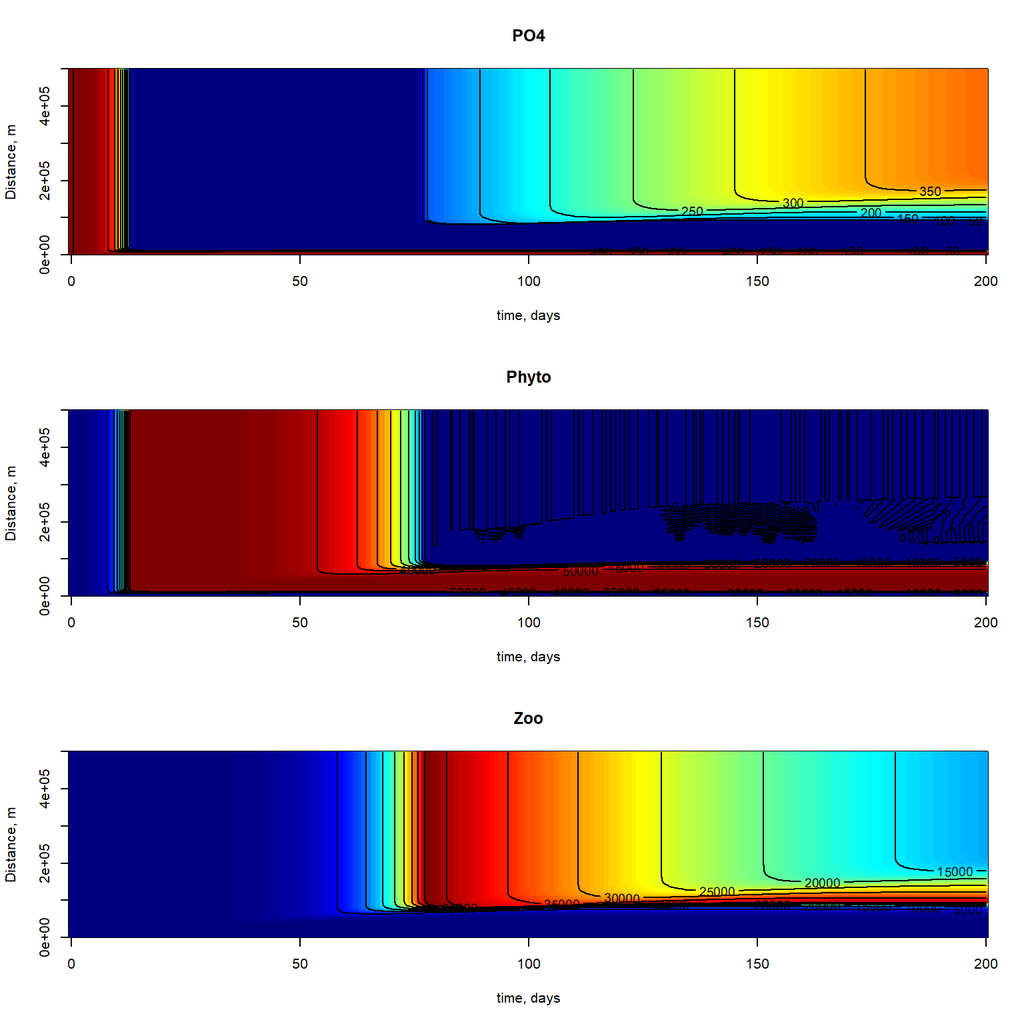

```r
image(dynamic, xlab = "time, days", ylab = "Distance, m", grid= Grid$x.mid,
      main =c("PO4","Phyto","Zoo"), add.contour=TRUE, mfrow = c(3, 1))
```

### Animated graphics

Here we want to create an animated figure. To make it well readable, we use filled polygons. First, a loop creates png images for each time step of the simulation and then **gifski** (Ooms 2021) puts this together and creates a gif-file.

```
## [1] "C:\\src\\packages\\Github\\dynamic-R\\aubergine\\work\\future\\river.gif"
```

[figure not shown]

```r
plot_poly <- function(data, time) {
  poly <- function(x, y, pcol, ylab, ylim) {
    plot(x, y, type="n", las=1, xlab="", ylab="", ylim=ylim)
    polygon(x, y, col=pcol, border=pcol, lty="blank")
    mtext(side=1, line=1.5, text="km")
    mtext(side=2, line=3.5, text=ylab, las=3)

  }
  y <- data[time, -1]
  N <- y[1:nbox]
  P <- y[(nbox+1):(2*nbox)]
  Z  <- y[(2*nbox+1):(3*nbox)]
  x   <- c(1, 1:nbox, nbox)
  #cat("time ", time, "\n")

  poly(x, c(0, N, 0), ylim=c(0,  1000), pcol="#a6cee3", ylab="P-PO4 (mmol/m3)")
  poly(x, c(0, P, 0), ylim=c(0, 70000), pcol="#b2df8a", ylab="Phyto (mmol/m3)")
  poly(x, c(0, Z, 0), ylim=c(0, 50000), pcol="#ee7f00", ylab="Zoo (mmol/m3)")
}

for (tt in time_seq)  {
  png(paste0("river", 1000 + tt, ".png"), width=1600, height=800, pointsize = 18)
  par(mfrow=c(3,1))
  par(mar=c(3,5,.5,0), las=1, cex.axis=1.4, cex.lab=1.4, cex.main=2)
  plot_poly(dynamic, tt)
  dev.off()
}

library("gifski")
gifski(dir(pattern="^river.*png$"), gif_file = "river.gif", width=1600, height=800, delay=1/25)
```

## Finally

Finally, we close the **future** workers and reset the strategy back to sequential.

```r
plan(strategy="sequential") # return to the default plan and close the workers
```

### References

Bengtsson, Henrik. 2020. “A Unifying Framework for Parallel and Distributed Processing in r Using Futures.” https://arxiv.org/abs/2008.00553.

FitzJohn, Rich. 2021. *odin: ODE Generation and Integration*. https://CRAN.R-project.org/package=odin.

Kaschek, Daniel, Wolfgang Mader, Mirjam Fehling-Kaschek, Marcus Rosenblatt, and Jens Timmer. 2019. “Dynamic Modeling, Parameter Estimation, and Uncertainty Analysis in R.” *Journal of Statistical Software* 88 (10): 1–32. https://doi.org/10.18637/jss.v088.i10.

Kneis, David. 2021. *rodeo: A Code Generator for ODE-Based Models*. https://CRAN.R-project.org/package=rodeo.

Kneis, David, Thomas Petzoldt, and Thomas U Berendonk. 2017. “An r-Package to Boost Fitness and Life Expectancy of Environmental Models.” *Environmental Modelling & Software* 96: 123–27. https://doi.org/10.1016/j.envsoft.2017.06.036.

Ooms, Jeroen. 2021. *Gifski: Highest Quality GIF Encoder*. https://CRAN.R-project.org/package=gifski.

Soetaert, Karline. 2021a. *OceanView: Visualisation of Oceanographic Data and Model Output*. https://CRAN.R-project.org/package=OceanView.

———. 2021b. *plot3D: Plotting Multi-Dimensional Data*. https://CRAN.R-project.org/package=plot3D.

Soetaert, Karline, Thomas Petzoldt, and R. Woodrow Setzer. 2010. “Solving Differential Equations in R: Package deSolve.” *Journal of Statistical Software* 33 (9): 1–25. https://doi.org/10.18637/jss.v033.i09.

Soetaert, K, and F Meysman. 2012. “Reactive Transport in Aquatic Ecosystems: Rapid Model Prototyping in the Open Source Software r.” *Environmental Modelling & Software* 32: 49–60.